# Targil 3

Shiran Ben-Meir 311308035 | Vadim Litvinov 314552365

In this project we would like to examine the impact of several health conditions and diseases on the chances of hospitalized patients to die. In addition, we will be assisted by age and sex features as predictors.

Those health conditions and diseases derived from Charlson-Comobidity-Index, a model that predicts the one-year mortality for a patient.

This data contains large number of medical features that will be ignored for the sake of focusing the Charlson-Comobidity-Index (+ sex and age).

```r
str(charlson_data)
```

```
## 'data.frame':    18890 obs. of  71 variables:
##  $ ן..prophylaxis.1                                    : int  0 0 0 0 0 0 1 1 0 0 ...
##  $ male.0.female.1                                     : chr  "1" "1" "0" "0" ...
##  $ weight                                              : chr  "83" "#NULL!" "85" "68.8" ...
##  $ height                                              : chr  "#NULL!" "#NULL!" "172" "170" ...
##  $ hospDuration                                        : int  4 4 4 3 7 3 10 6 3 5 ...
##  $ prevHosp                                            : int  0 0 0 0 1 0 0 0 0 1 ...
##  $ placeResidence                                      : int  0 0 0 0 0 0 1 0 0 0 ...
##  $ functionalStatus                                    : chr  "Independant" "Weak" "Independant" "Independant" ...
##  $ smoking                                             : chr  "no" "" "yes" "yes" ...
##  $ pressureUlcers                                      : int  0 1 0 0 0 0 0 0 0 0 ...
##  $ feverFirst                                          : chr  "36.5" "36.7" "36.7" "36.7" ...
##  $ feverMax                                            : chr  "36.5" "37.2" "37.1" "36.8" ...
##  $ BPsFirst                                            : chr  "159" "153" "135" "196" ...
##  $ BPdFirst                                            : chr  "93" "70" "71" "105" ...
```

[output cut: 57 more lines]

```r
#charlson_data
```

This big data has a lot of candidate variables for classification prediction. It can be suggested to predict Major bleeding, BMI, VTE (Venous Thrombo Embolism) or death.

First we will delete all features that dont belong to Charlson-Comobidity-Index, sex, age and death. Moreover, we will delete the features: Charlson.Leukemia and Charlson.lymphoma because they are included in the feature: Charlson.lymphoma.or.leukemia. From the same reason we deleted Charlson.severe.renal.disease that hides in Charlson.moderate.to.severe.renal.disease, and the same for Charlson.Metastatic.solid.tumor and Charlson.Metastatic.solid.tumor.3.

```r
charlson_data = subset(charlson_data, select = c(2,43,44,45,46,47,50,51,52,54,55,56,57,58,59,60,61,66,70) )
str(charlson_data)
```

```
## 'data.frame':    18890 obs. of  19 variables:
##  $ male.0.female.1                                     : chr  "1" "1" "0" "0" ...
##  $ Charlson.Myocardial.Infarct                         : int  0 0 0 0 0 0 0 0 0 0 ...
##  $ Charlson.Pulmonary.congestion                       : int  0 0 0 0 0 0 0 0 0 0 ...
##  $ Charlson.PVD                                        : int  0 0 0 0 0 0 0 0 0 0 ...
##  $ Charlson.DB                                         : int  0 0 0 0 0 0 1 0 0 0 ...
##  $ Charlson.DM...retinopathy...neuropathy...nephropathy: int  0 0 0 0 0 0 0 0 0 0 ...
##  $ Charlson.lymphoma.or.leukemia                       : int  0 0 0 0 0 0 0 0 0 1 ...
##  $ Charlson.cerebrovascular.disease                    : int  0 0 0 0 0 0 0 0 0 0 ...
##  $ Charlson.Hemiplegia                                 : int  0 0 0 0 0 0 0 0 0 0 ...
##  $ Charlson.Dementia                                   : int  0 0 0 0 0 0 0 0 0 0 ...
##  $ Charlson.chronic.pulmonary.diseas                   : int  0 0 0 0 0 1 1 0 1 0 ...
##  $ Charlson.Connective.tissue.disease                  : int  0 0 0 0 0 0 0 0 0 0 ...
##  $ Charlson.Peptic.ulcer.disease                       : int  0 0 0 0 0 0 0 0 0 0 ...
##  $ Charlson.AIDS                                       : int  0 0 0 0 0 0 0 0 0 0 ...
##  $ Charlson.Metastatic.solid.tumor.3                   : int  0 0 0 0 0 0 0 0 0 0 ...
##  $ Charlson.moderate.to.severe.renal.disease           : int  0 0 0 0 0 0 0 0 0 0 ...
##  $ Charlson.liver.disease                              : int  0 0 0 0 0 0 0 0 0 0 ...
##  $ death                                               : chr  "0" "0" "0" "0" ...
##  $ age                                                 : num  69.9 89.3 32.1 47.8 90.1 ...
```

This data contains information about 18,890 patients. All variables are binary except age variable.

sex - male/female.

Charlson.Myocardial.Infarct - Myocardial Infarction (Heart Attack).

Charlson.Pulmonary.congestion - Pulmonary congestion condition.

Charlson.PVD - Peripheral vascular disease.

Charlson.DB - Diabetes disease.

Charlson.DM+ retinopathy/neuropathy/nephropathy - retinopathy or neuropathy or nephropathy caused by Diabetes mellitus.

Charlson.lymphoma.or.leukemia - cancer type of Lymphoma or Leukemia.

Charlson.cerebrovascular.disease - cerebrovascular disease.

Charlson.Hemiplegia - Hemiplegia condition.

Charlson.Dementia - Dementia disease.

Charlson.chronic.pulmonary.diseas - chronic pulmonary disease.

Charlson.Connective.tissue.disease - Connective tissue disease.

Charlson.Peptic.ulcer.disease - Ulcer condition.

Charlson.AIDS - Acquired Immune Deficiency Syndrome.

Charlson.Metastatic.solid.tumor.3 - Malignant metastatic tumor stage 3.

Charlson.moderate.to.severe.renal.disease - moderate or severe kidney disease.

Charlson.liver.disease - Liver disease.

death - binary, died or not.

age - numeric, age of the patient.

For the sake of more readable variables we shall change their names.

```r
charlson_data<-rename(charlson_data, c("gender" = "male.0.female.1","Myocardial.Infarct" = "Charlson.Myocardial.Infarct", "Pulmonary.congestion" = "Charlson.Pulmonary.congestion","Peripheral vascular disease" = "Charlson.PVD","Diabetes" = "Charlson.DB","lymphoma.or.leukemia" = "Charlson.lymphoma.or.leukemia","cerebrovascular.disease" = "Charlson.cerebrovascular.disease","Hemiplegia" = "Charlson.Hemiplegia","Dementia" = "Charlson.Dementia","chronic.pulmonary.disease" = "Charlson.chronic.pulmonary.diseas","Connective.tissue.disease" = "Charlson.Connective.tissue.disease","Peptic.ulcer.disease" = "Charlson.Peptic.ulcer.disease","AIDS" = "Charlson.AIDS","Metastatic.solid.tumor.3" = "Charlson.Metastatic.solid.tumor.3","moderate.to.severe.renal.disease" = "Charlson.moderate.to.severe.renal.disease","liver.disease" = "Charlson.liver.disease","DM+retinopathy/neuropathy/nephropathy" = "Charlson.DM...retinopathy...neuropathy...nephropathy"))
```

We will delete NA values if exists on any of the features or classification variable. Moreover, it has been noticed that the gender and death columns are the only ones to have missing values of type: “#NULL!”, therefore we will handle that.

```r
charlson_data <- na.omit(charlson_data)
#handling missing values that are not NA
charlson_data <- charlson_data[charlson_data$gender != "#NULL!" ,]
charlson_data <- charlson_data[charlson_data$death != "#NULL!" ,]
```

For the exploration part, we will examine 4 features and the classification variable. The 4 features inculdes 2 major diseases that we think will be tightly binded to chances of dying - Myocardial Infarction and Metastatic solid tumor stage 3. We also represent the numeric age variable divided to range of ages and the gender variable.

gender variable -

```r
table(charlson_data$gender)
```

```
##
##    0    1
## 9697 9187
```

```r
round(prop.table(table(charlson_data$gender)), digits = 1)
```

```
##
##   0   1
## 0.5 0.5
```

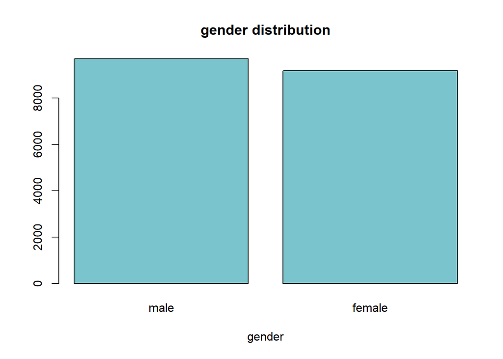

```r
barplot(table(charlson_data$gender),
   xlab="gender", col="cadetblue3", main= "gender distribution", names.arg=c("male","female"))
```

Myocardial Infarction variable -

```r
table(charlson_data$Myocardial.Infarct)
```

```
##
##     0     1
## 16855  2029
```

```r
round(prop.table(table(charlson_data$Myocardial.Infarct)), digits = 1)
```

```
##
##   0   1
## 0.9 0.1
```

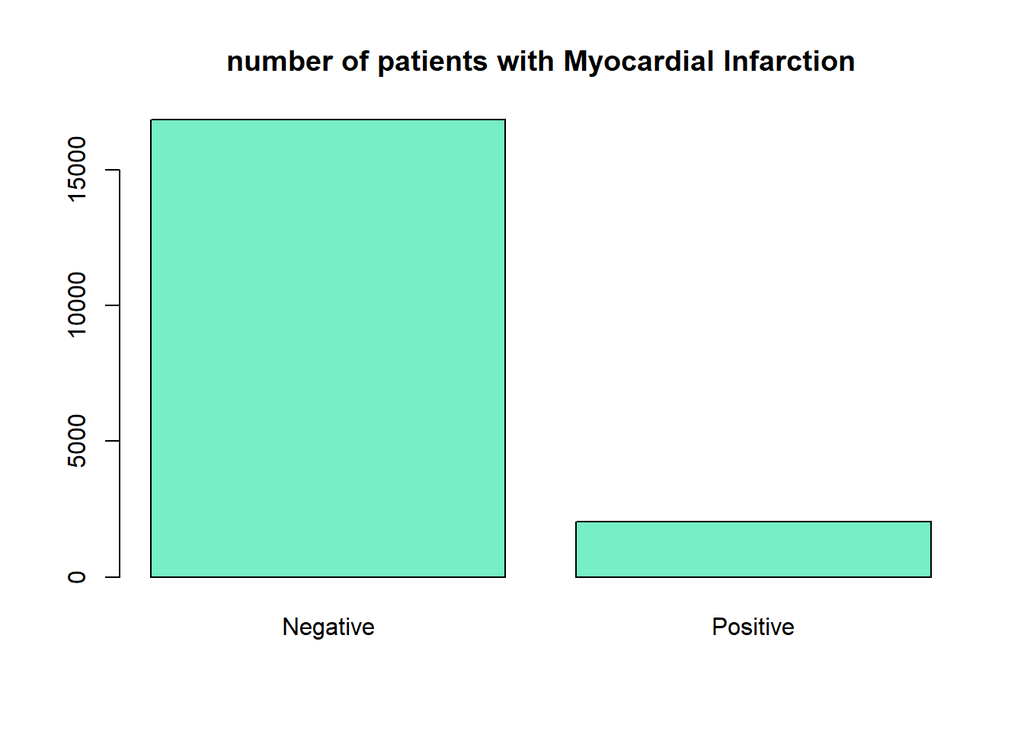

```r
barplot(table(charlson_data$Myocardial.Infarct), col="aquamarine2",main="number of patients with Myocardial Infarction",names.arg=c("Negative","Positive"))
```

Metastatic solid tumor 3 variable -

```r
table(charlson_data$Metastatic.solid.tumor.3)
```

```
##
##     0     1
## 16483  2401
```

```r
round(prop.table(table(charlson_data$Metastatic.solid.tumor.3)), digits = 1)
```

```
##
##   0   1
## 0.9 0.1
```

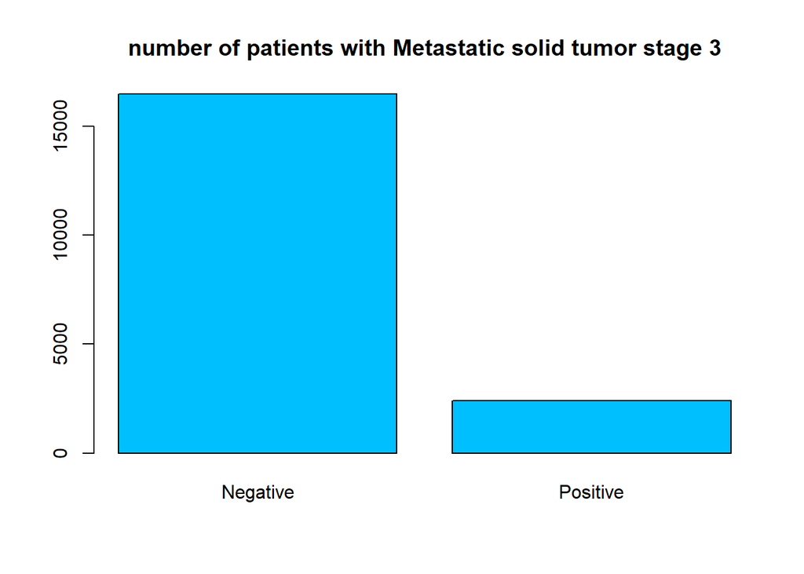

```r
barplot(table(charlson_data$Metastatic.solid.tumor.3), col="deepskyblue",main = "number of patients with Metastatic solid tumor stage 3",names.arg=c("Negative","Positive"))
```

age variable -

```r
summary(charlson_data$age)
```

```
##    Min. 1st Qu.  Median    Mean 3rd Qu.    Max.
##   18.02   53.43   67.17   64.65   79.27  116.25
```

```r
charlson_data[, 18] <- as.numeric(as.character( charlson_data[, 18] ))
Age <- cut(charlson_data$age, breaks = c(0,20,40,60,80,100,Inf),labels = c("0-20","20-40","40-60","60-80","80-100","100+"))

aggregate(death ~ Age, charlson_data, sum)
```

```
##      Age death
## 1   0-20     6
## 2  20-40    93
## 3  40-60   523
## 4  60-80  1922
## 5 80-100  1801
## 6   100+    19
```

[figure not shown]

```r
barplot(table(Age), ylab='number of dead patients', xlab="ages",col="lightblue1",main = "age distribution")
```

death variable (classification variable) -

```r
table(charlson_data$death)
```

```
##
##     0     1
## 14520  4364
```

```r
round(prop.table(table(charlson_data$death)), digits = 1)
```

```
##
##   0   1
## 0.8 0.2
```

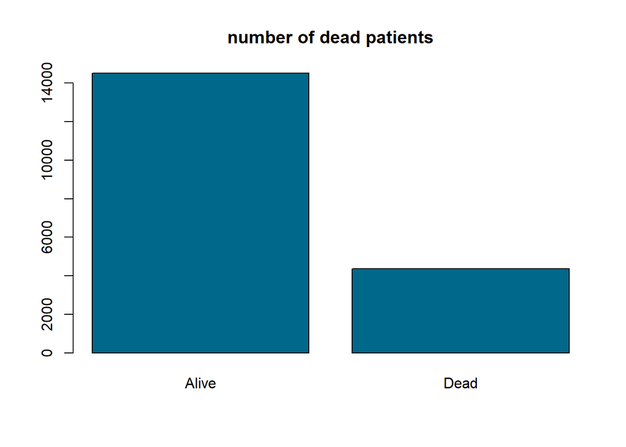

```r
barplot(table(charlson_data$death), col="deepskyblue4", main = "number of dead patients",,names.arg=c("Alive","Dead"))
```

Now we will proceed forward to the prediction part, we will use KNN learning algorithm.

```r
#normalization function:
normalize <- function(x){
  return((x-min(x)) / (max(x)-min(x)))
}

#normalization
n_charlson_data= as.data.frame(lapply(charlson_data[19], normalize))
```

```r
#merging data
normalizedData <-data.frame(charlson_data)
normalizedData <- normalizedData[,-c(19)]
normalizedData <-cbind(normalizedData, n_charlson_data)
```

The partition that has been chosen is train-set (70%) and test-set (30%).

```r
train_charlson_data= normalizedData[1:13218,]
test_charlson_data= normalizedData[13219:18884,]


train_labels= normalizedData[1:13218, 18]
test_labels= normalizedData[13219:18884, 18]
```

```r
test_pred <- knn(train = train_charlson_data, test = test_charlson_data , cl= train_labels, k=1)
CrossTable(x= test_labels, y= test_pred, prop.chisq = FALSE)
```

```
##
##
##    Cell Contents
## |-------------------------|
## |                       N |
## |           N / Row Total |
## |           N / Col Total |
## |         N / Table Total |
## |-------------------------|
##
##
## Total Observations in Table:  5666
##
##
##              | test_pred
##  test_labels |         0 |         1 | Row Total |
## -------------|-----------|-----------|-----------|
##            0 |      4350 |         1 |      4351 |
##              |     1.000 |     0.000 |     0.768 |
##              |     1.000 |     0.001 |           |
##              |     0.768 |     0.000 |           |
## -------------|-----------|-----------|-----------|
##            1 |         2 |      1313 |      1315 |
##              |     0.002 |     0.998 |     0.232 |
##              |     0.000 |     0.999 |           |
##              |     0.000 |     0.232 |           |
## -------------|-----------|-----------|-----------|
## Column Total |      4352 |      1314 |      5666 |
##              |     0.768 |     0.232 |           |
## -------------|-----------|-----------|-----------|
##
##
```

In general, the low error-rate is as well achived beacuse of the good big data (18,890 cases before substracion), low number of missing values to substract (6 cases overall), and the approximately balanced data in the classification variable (23.11%/76.89%).

Research questions:

1. We would like to examine the impact of also other variables in the data that were ignored in the exploration part on the chances of dying.
2. What features (medical conditions or other) can help to predict if the patient will recive a VTE (Venous Thrombo Embolism) during hospitalization or not?
3. What medical conditions, drugs or other features can predict if the patient will be having major bleeding during his hospitalization?

Those questions are interesting in general beacuse they are tightely connected to life threatening conditions and has a high medical importence. In addition, those variables are binary and well defiend, which can be of aid to the algorithm and simplicity of understanding its results.